# C. elegans Smaller Gene Set GO Analysis - Manuscript Method

clusterProfiler over-representation analysis with BH correction

June 01, 2026

# Purpose

This report reruns the smaller *C. elegans* gene set using the same over-representation approach used in the manuscript-style analysis: `clusterProfiler::enrichGO()` with Benjamini-Hochberg (BH) multiple-testing correction. This is intentionally different from the later `topGO` analysis. The goal is to document that the smaller gene set does not yield significant BH-adjusted GO terms under the stricter manuscript method.

# Packages

```r
required_pkgs <- c(
  "readxl", "dplyr", "ggplot2", "clusterProfiler", "org.Ce.eg.db",
  "enrichplot", "knitr", "kableExtra"
)

missing_pkgs <- required_pkgs[
  !sapply(required_pkgs, requireNamespace, quietly = TRUE)
]
if (length(missing_pkgs) > 0) {
  BiocManager::install(missing_pkgs, ask = FALSE)
}

invisible(lapply(required_pkgs, library, character.only = TRUE))
```

# Gene Input

```r
file_path_worm <- "./05-2026/list of genes_resubmission.xlsx"
worm_df <- readxl::read_excel(file_path_worm)

wb_col <- grep("WormBase.*Gene|WBGene", names(worm_df),
               ignore.case = TRUE, value = TRUE)[1]
sym_col <- grep("^Gene$|Gene.*[Ss]ymbol|[Ss]ymbol|gene.*name",
                names(worm_df), ignore.case = TRUE, value = TRUE)[1]

cat("Input file:", file_path_worm, "\n")
```

```
## Input file: ./05-2026/list of genes_resubmission.xlsx
```

```r
cat("Total input genes:", nrow(worm_df), "\n")
```

```
## Total input genes: 18
```

```r
cat("WormBase ID column:", wb_col, "\n")
```

```
## WormBase ID column: WormBase Gene ID
```

```r
cat("Gene symbol column:", sym_col, "\n")
```

```
## Gene symbol column: Gene
```

# ID Mapping

```r
map_to_entrez <- function(ids, from_type) {
  ids <- na.omit(unique(ids))
  if (length(ids) == 0) {
    return(data.frame(ENTREZID = character()))
  }

  suppressMessages(
    clusterProfiler::bitr(
      ids,
      fromType = from_type,
      toType = "ENTREZID",
      OrgDb = org.Ce.eg.db
    )
  )
}

wb_ids <- if (!is.na(wb_col)) na.omit(unique(worm_df[[wb_col]])) else character()
sym_ids <- if (!is.na(sym_col)) na.omit(unique(worm_df[[sym_col]])) else character()

map_wb <- map_to_entrez(wb_ids, "WORMBASE")
map_sym <- map_to_entrez(sym_ids, "SYMBOL")

mapping_summary <- data.frame(
  `ID type` = c("WormBase (WORMBASE)", "Gene Symbol (SYMBOL)"),
  `Input genes` = c(length(wb_ids), length(sym_ids)),
  `Mapped Entrez IDs` = c(
    length(unique(map_wb$ENTREZID)),
    length(unique(map_sym$ENTREZID))
  ),
  check.names = FALSE
)

knitr::kable(
  mapping_summary,
  booktabs = TRUE,
  caption = "Entrez ID mapping summary for the smaller gene set"
) |>
  kableExtra::kable_styling(
    latex_options = c("hold_position", "striped"),
    font_size = 10
  )
```

Entrez ID mapping summary for the smaller gene set

| ID type | Input genes | Mapped Entrez IDs |
| --- | --- | --- |
| WormBase (WORMBASE) | 18 | 18 |
| Gene Symbol (SYMBOL) | 18 | 18 |

```r
if (length(unique(map_sym$ENTREZID)) > length(unique(map_wb$ENTREZID))) {
  worm_entrez <- unique(map_sym$ENTREZID)
  id_method <- "Gene Symbol -> Entrez"
} else {
  worm_entrez <- unique(map_wb$ENTREZID)
  id_method <- "WormBase ID -> Entrez"
}

cat("Selected mapping method:", id_method, "\n")
```

```
## Selected mapping method: WormBase ID -> Entrez
```

```r
cat("Mapped query genes:", length(worm_entrez), "\n")
```

```
## Mapped query genes: 18
```

# Manuscript-Style GO Enrichment

GO over-representation analysis was performed using `enrichGO()` with BH multiple-testing correction. All terms were retained for reporting and plotting, but terms were considered significant only if they met the adjusted threshold used in the manuscript-style workflow.

```r
run_go <- function(ontology) {
  clusterProfiler::enrichGO(
    gene = worm_entrez,
    OrgDb = org.Ce.eg.db,
    keyType = "ENTREZID",
    ont = ontology,
    pAdjustMethod = "BH",
    pvalueCutoff = 1,
    qvalueCutoff = 1,
    minGSSize = 3,
    readable = TRUE
  )
}

ego_ce_bp <- run_go("BP")
ego_ce_mf <- run_go("MF")
ego_ce_cc <- run_go("CC")

bp_all <- ego_ce_bp@result
mf_all <- ego_ce_mf@result
cc_all <- ego_ce_cc@result

result_summary <- data.frame(
  Ontology = c("Biological Process", "Molecular Function", "Cellular Component"),
  `Terms tested/returned` = c(nrow(bp_all), nrow(mf_all), nrow(cc_all)),
  `Nominal raw p < 0.05` = c(
    sum(bp_all$pvalue < 0.05, na.rm = TRUE),
    sum(mf_all$pvalue < 0.05, na.rm = TRUE),
    sum(cc_all$pvalue < 0.05, na.rm = TRUE)
  ),
  `Terms with BH adjusted p < 0.05` = c(
    sum(bp_all$p.adjust < 0.05, na.rm = TRUE),
    sum(mf_all$p.adjust < 0.05, na.rm = TRUE),
    sum(cc_all$p.adjust < 0.05, na.rm = TRUE)
  ),
  `Terms with q < 0.2` = c(
    sum(bp_all$qvalue < 0.2, na.rm = TRUE),
    sum(mf_all$qvalue < 0.2, na.rm = TRUE),
    sum(cc_all$qvalue < 0.2, na.rm = TRUE)
  ),
  check.names = FALSE
)

knitr::kable(
  result_summary,
  booktabs = TRUE,
  caption = "Summary of manuscript-style GO enrichment results"
) |>
  kableExtra::kable_styling(
    latex_options = c("hold_position", "striped"),
    font_size = 10
  )
```

Summary of manuscript-style GO enrichment results

| Ontology | Terms tested/returned | Nominal raw p < 0.05 | Terms with BH adjusted p < 0.05 | Terms with q < 0.2 |
| --- | --- | --- | --- | --- |
| Biological Process | 3683 | 102 | 0 | 0 |
| Molecular Function | 1299 | 25 | 0 | 0 |
| Cellular Component | 758 | 13 | 0 | 0 |

## Biological Process

```r
if (nrow(bp_all) == 0) {
  cat("No Biological Process GO terms were significant after BH correction.")
} else {
  bp_show <- bp_all |>
    dplyr::arrange(pvalue) |>
    dplyr::slice_head(n = 20) |>
    dplyr::select(
      ID, Description, GeneRatio, BgRatio, pvalue, p.adjust, qvalue, geneID, Count
    )

  knitr::kable(
    bp_show,
    booktabs = TRUE,
    digits = 4,
    caption = "C. elegans Biological Process GO results using manuscript method"
  ) |>
    kableExtra::kable_styling(
      latex_options = c("scale_down", "hold_position", "striped"),
      font_size = 8
    )
}
```

C. elegans Biological Process GO results using manuscript method

|  | ID | Description | GeneRatio | BgRatio | pvalue | p.adjust | qvalue | geneID | Count |
| --- | --- | --- | --- | --- | --- | --- | --- | --- | --- |
| GO:0006893 | GO:0006893 | Golgi to plasma membrane transport | 2/15 | 19/9469 | 0.0004 | 1 | 1 | tom-1/ath-1 | 2 |
| GO:0006892 | GO:0006892 | post-Golgi vesicle-mediated transport | 2/15 | 30/9469 | 0.0010 | 1 | 1 | tom-1/ath-1 | 2 |
| GO:0032880 | GO:0032880 | regulation of protein localization | 3/15 | 148/9469 | 0.0015 | 1 | 1 | spe-6/ath-1/pry-1 | 3 |
| GO:0032879 | GO:0032879 | regulation of localization | 4/15 | 345/9469 | 0.0017 | 1 | 1 | spe-6/tom-1/ath-1/pry-1 | 4 |
| GO:0098876 | GO:0098876 | vesicle-mediated transport to the plasma membrane | 2/15 | 51/9469 | 0.0029 | 1 | 1 | tom-1/ath-1 | 2 |
| GO:0099161 | GO:0099161 | regulation of presynaptic dense core granule exocytosis | 1/15 | 4/9469 | 0.0063 | 1 | 1 | tom-1 | 1 |
| GO:0099171 | GO:0099171 | presynaptic modulation of chemical synaptic transmission | 1/15 | 4/9469 | 0.0063 | 1 | 1 | tom-1 | 1 |
| GO:1903233 | GO:1903233 | regulation of calcium ion-dependent exocytosis of neurotransmitter | 1/15 | 4/9469 | 0.0063 | 1 | 1 | tom-1 | 1 |
| GO:1905413 | GO:1905413 | regulation of dense core granule exocytosis | 1/15 | 4/9469 | 0.0063 | 1 | 1 | tom-1 | 1 |
| GO:0007283 | GO:0007283 | spermatogenesis | 2/15 | 77/9469 | 0.0064 | 1 | 1 | spe-6/F26E4.5 | 2 |
| GO:0048232 | GO:0048232 | male gamete generation | 2/15 | 82/9469 | 0.0072 | 1 | 1 | spe-6/F26E4.5 | 2 |
| GO:0051247 | GO:0051247 | positive regulation of protein metabolic process | 2/15 | 86/9469 | 0.0079 | 1 | 1 | pry-1/gba-4 | 2 |
| GO:0006680 | GO:0006680 | glucosylceramide catabolic process | 1/15 | 6/9469 | 0.0095 | 1 | 1 | gba-4 | 1 |
| GO:0015937 | GO:0015937 | coenzyme A biosynthetic process | 1/15 | 6/9469 | 0.0095 | 1 | 1 | pnk-1 | 1 |
| GO:0016082 | GO:0016082 | synaptic vesicle priming | 1/15 | 6/9469 | 0.0095 | 1 | 1 | tom-1 | 1 |
| GO:0045089 | GO:0045089 | positive regulation of innate immune response | 1/15 | 6/9469 | 0.0095 | 1 | 1 | akir-1 | 1 |
| GO:0060627 | GO:0060627 | regulation of vesicle-mediated transport | 2/15 | 97/9469 | 0.0100 | 1 | 1 | tom-1/ath-1 | 2 |
| GO:0043001 | GO:0043001 | Golgi to plasma membrane protein transport | 1/15 | 7/9469 | 0.0110 | 1 | 1 | ath-1 | 1 |
| GO:0046477 | GO:0046477 | glycosylceramide catabolic process | 1/15 | 7/9469 | 0.0110 | 1 | 1 | gba-4 | 1 |
| GO:0051224 | GO:0051224 | negative regulation of protein transport | 1/15 | 7/9469 | 0.0110 | 1 | 1 | ath-1 | 1 |

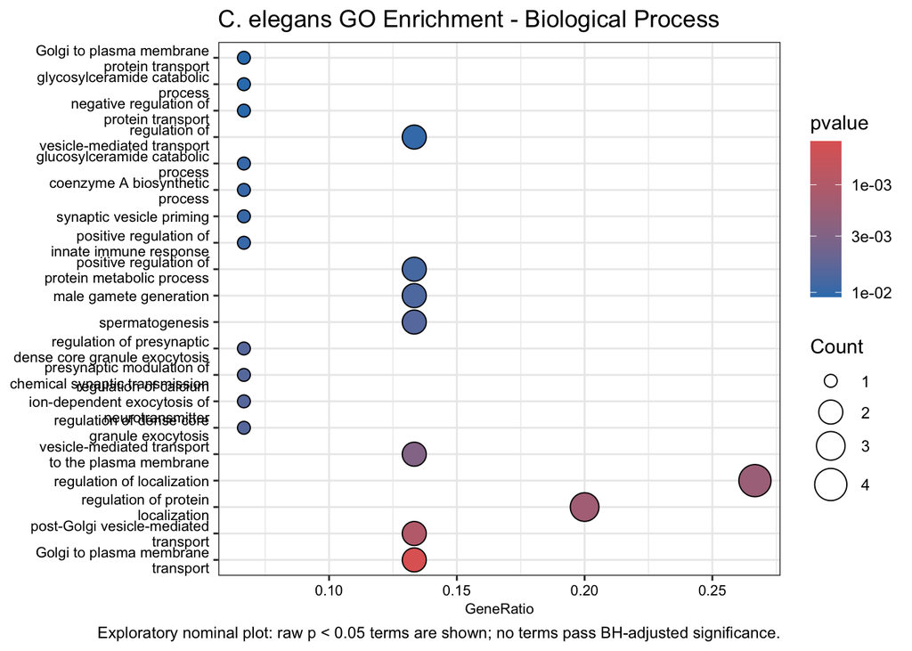

## Molecular Function

```r
if (nrow(mf_all) == 0) {
  cat("No Molecular Function GO terms were significant after BH correction.")
} else {
  mf_show <- mf_all |>
    dplyr::arrange(pvalue) |>
    dplyr::slice_head(n = 20) |>
    dplyr::select(
      ID, Description, GeneRatio, BgRatio, pvalue, p.adjust, qvalue, geneID, Count
    )

  knitr::kable(
    mf_show,
    booktabs = TRUE,
    digits = 4,
    caption = "C. elegans Molecular Function GO results using manuscript method"
  ) |>
    kableExtra::kable_styling(
      latex_options = c("scale_down", "hold_position", "striped"),
      font_size = 8
    )
}
```

C. elegans Molecular Function GO results using manuscript method

|  | ID | Description | GeneRatio | BgRatio | pvalue | p.adjust | qvalue | geneID | Count |
| --- | --- | --- | --- | --- | --- | --- | --- | --- | --- |
| GO:0045159 | GO:0045159 | myosin II binding | 1/15 | 4/9751 | 0.0061 | 1 | 1 | tom-1 | 1 |
| GO:0030674 | GO:0030674 | protein-macromolecule adaptor activity | 3/15 | 263/9751 | 0.0069 | 1 | 1 | sin-3/pry-1/akir-1 | 3 |
| GO:0005247 | GO:0005247 | voltage-gated chloride channel activity | 1/15 | 5/9751 | 0.0077 | 1 | 1 | clh-5 | 1 |
| GO:0008131 | GO:0008131 | primary methylamine oxidase activity | 1/15 | 5/9751 | 0.0077 | 1 | 1 | mig-38 | 1 |
| GO:0060090 | GO:0060090 | molecular adaptor activity | 3/15 | 287/9751 | 0.0088 | 1 | 1 | sin-3/pry-1/akir-1 | 3 |
| GO:0004348 | GO:0004348 | glucosylceramidase activity | 1/15 | 6/9751 | 0.0092 | 1 | 1 | gba-4 | 1 |
| GO:0016641 | GO:0016641 | oxidoreductase activity, acting on the CH-NH2 group of donors, oxygen as acceptor | 1/15 | 6/9751 | 0.0092 | 1 | 1 | mig-38 | 1 |
| GO:0017042 | GO:0017042 | glycosylceramidase activity | 1/15 | 7/9751 | 0.0107 | 1 | 1 | gba-4 | 1 |
| GO:0008308 | GO:0008308 | voltage-gated monoatomic anion channel activity | 1/15 | 8/9751 | 0.0122 | 1 | 1 | clh-5 | 1 |
| GO:0008474 | GO:0008474 | palmitoyl-(protein) hydrolase activity | 1/15 | 8/9751 | 0.0122 | 1 | 1 | ath-1 | 1 |
| GO:0098599 | GO:0098599 | palmitoyl hydrolase activity | 1/15 | 8/9751 | 0.0122 | 1 | 1 | ath-1 | 1 |
| GO:0003712 | GO:0003712 | transcription coregulator activity | 2/15 | 117/9751 | 0.0135 | 1 | 1 | sin-3/akir-1 | 2 |
| GO:0004300 | GO:0004300 | enoyl-CoA hydratase activity | 1/15 | 9/9751 | 0.0138 | 1 | 1 | ech-7 | 1 |
| GO:0048038 | GO:0048038 | quinone binding | 1/15 | 9/9751 | 0.0138 | 1 | 1 | mig-38 | 1 |
| GO:0016638 | GO:0016638 | oxidoreductase activity, acting on the CH-NH2 group of donors | 1/15 | 10/9751 | 0.0153 | 1 | 1 | mig-38 | 1 |
| GO:0004407 | GO:0004407 | histone deacetylase activity | 1/15 | 13/9751 | 0.0198 | 1 | 1 | sin-3 | 1 |
| GO:0008013 | GO:0008013 | beta-catenin binding | 1/15 | 13/9751 | 0.0198 | 1 | 1 | pry-1 | 1 |
| GO:0033558 | GO:0033558 | protein lysine deacetylase activity | 1/15 | 13/9751 | 0.0198 | 1 | 1 | sin-3 | 1 |
| GO:0005507 | GO:0005507 | copper ion binding | 1/15 | 15/9751 | 0.0228 | 1 | 1 | mig-38 | 1 |
| GO:0017022 | GO:0017022 | myosin binding | 1/15 | 15/9751 | 0.0228 | 1 | 1 | tom-1 | 1 |

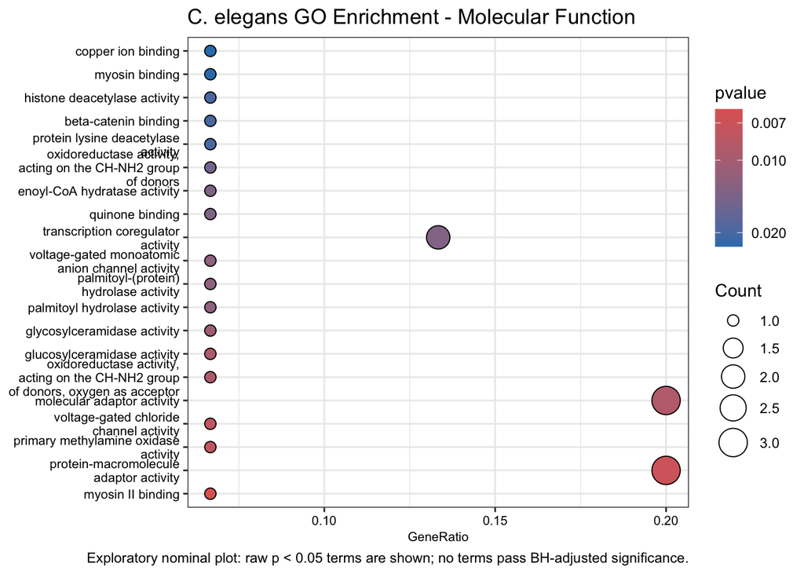

## Cellular Component

```r
if (nrow(cc_all) == 0) {
  cat("No Cellular Component GO terms were significant after BH correction.")
} else {
  cc_show <- cc_all |>
    dplyr::arrange(pvalue) |>
    dplyr::slice_head(n = 20) |>
    dplyr::select(
      ID, Description, GeneRatio, BgRatio, pvalue, p.adjust, qvalue, geneID, Count
    )

  knitr::kable(
    cc_show,
    booktabs = TRUE,
    digits = 4,
    caption = "C. elegans Cellular Component GO results using manuscript method"
  ) |>
    kableExtra::kable_styling(
      latex_options = c("scale_down", "hold_position", "striped"),
      font_size = 8
    )
}
```

C. elegans Cellular Component GO results using manuscript method

|  | ID | Description | GeneRatio | BgRatio | pvalue | p.adjust | qvalue | geneID | Count |
| --- | --- | --- | --- | --- | --- | --- | --- | --- | --- |
| GO:0099503 | GO:0099503 | secretory vesicle | 2/16 | 74/12490 | 0.0039 | 1 | 1 | tom-1/clh-5 | 2 |
| GO:0030667 | GO:0030667 | secretory granule membrane | 1/16 | 4/12490 | 0.0051 | 1 | 1 | tom-1 | 1 |
| GO:0098981 | GO:0098981 | cholinergic synapse | 1/16 | 6/12490 | 0.0077 | 1 | 1 | tom-1 | 1 |
| GO:0098793 | GO:0098793 | presynapse | 2/16 | 122/12490 | 0.0104 | 1 | 1 | tom-1/clh-5 | 2 |
| GO:0031045 | GO:0031045 | dense core granule | 1/16 | 10/12490 | 0.0127 | 1 | 1 | tom-1 | 1 |
| GO:0031312 | GO:0031312 | extrinsic component of organelle membrane | 1/16 | 10/12490 | 0.0127 | 1 | 1 | tom-1 | 1 |
| GO:0031594 | GO:0031594 | neuromuscular junction | 1/16 | 19/12490 | 0.0241 | 1 | 1 | tom-1 | 1 |
| GO:0030141 | GO:0030141 | secretory granule | 1/16 | 26/12490 | 0.0328 | 1 | 1 | tom-1 | 1 |
| GO:0030659 | GO:0030659 | cytoplasmic vesicle membrane | 2/16 | 231/12490 | 0.0345 | 1 | 1 | tom-1/clh-5 | 2 |
| GO:0000118 | GO:0000118 | histone deacetylase complex | 1/16 | 28/12490 | 0.0353 | 1 | 1 | sin-3 | 1 |
| GO:0012506 | GO:0012506 | vesicle membrane | 2/16 | 236/12490 | 0.0358 | 1 | 1 | tom-1/clh-5 | 2 |
| GO:0000785 | GO:0000785 | chromatin | 2/16 | 251/12490 | 0.0401 | 1 | 1 | sin-3/akir-1 | 2 |
| GO:0031201 | GO:0031201 | SNARE complex | 1/16 | 32/12490 | 0.0402 | 1 | 1 | tom-1 | 1 |
| GO:0008021 | GO:0008021 | synaptic vesicle | 1/16 | 47/12490 | 0.0586 | 1 | 1 | clh-5 | 1 |
| GO:0019898 | GO:0019898 | extrinsic component of membrane | 1/16 | 52/12490 | 0.0646 | 1 | 1 | tom-1 | 1 |
| GO:0070382 | GO:0070382 | exocytic vesicle | 1/16 | 54/12490 | 0.0670 | 1 | 1 | clh-5 | 1 |
| GO:0005769 | GO:0005769 | early endosome | 1/16 | 60/12490 | 0.0742 | 1 | 1 | clh-5 | 1 |
| GO:0045202 | GO:0045202 | synapse | 2/16 | 361/12490 | 0.0766 | 1 | 1 | tom-1/clh-5 | 2 |
| GO:0031410 | GO:0031410 | cytoplasmic vesicle | 2/16 | 422/12490 | 0.1001 | 1 | 1 | tom-1/clh-5 | 2 |
| GO:0097708 | GO:0097708 | intracellular vesicle | 2/16 | 423/12490 | 0.1005 | 1 | 1 | tom-1/clh-5 | 2 |

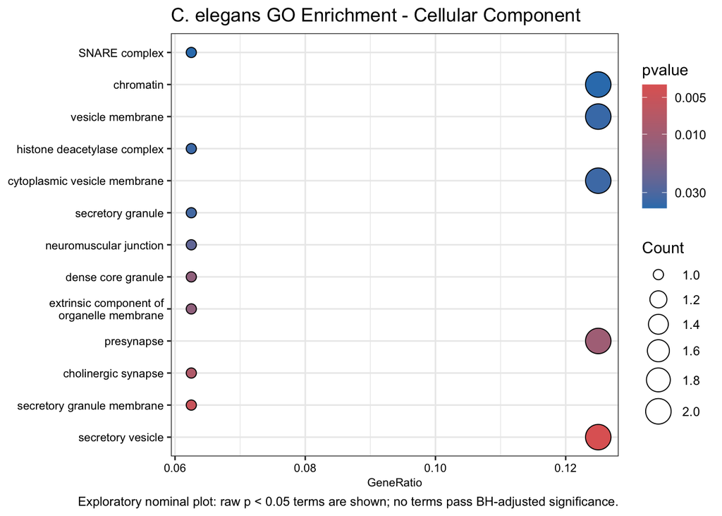

# Export Results

```r
out_dir <- "output_tables_smaller_gene_set_manuscript_method"
dir.create(out_dir, showWarnings = FALSE)

write.csv(bp_all, file.path(out_dir, "Worm_GO_BP_BH_corrected.csv"), row.names = FALSE)
write.csv(mf_all, file.path(out_dir, "Worm_GO_MF_BH_corrected.csv"), row.names = FALSE)
write.csv(cc_all, file.path(out_dir, "Worm_GO_CC_BH_corrected.csv"), row.names = FALSE)
write.csv(result_summary, file.path(out_dir, "GO_BH_corrected_summary.csv"), row.names = FALSE)

cat("Results exported to", out_dir, "\n")
```

```
## Results exported to output_tables_smaller_gene_set_manuscript_method
```

# Conclusion

Using the manuscript-style `clusterProfiler::enrichGO()` workflow with BH correction, the smaller *C. elegans* query set did not produce significant GO enrichment terms. This supports the interpretation that the lack of significance is due to the small query size and multiple-testing burden, rather than a failure of ID mapping. The later `topGO weight01` analysis should therefore be viewed as a hierarchy-aware follow-up method for extracting directional biological signal from a small, focused gene list.